# Bayesian Additive Regression Trees for Multivariate skewed responses

Seungha Um

Last Updated - Jan 30, 2022

## Introduction

This function implements the methodology described in the paper

- Um, S. & Linero A. & Sinha D. & Bandyopadhyay D. (2021). *Bayesian Additive Regression Trees for Multivariate skewed responses*  
  [[paper]](https://github.com/Seungha-Um/skewBART)[[Github]](https://github.com/Seungha-Um/skewBART)

## Model

Our proposed model is an extension of BART to accommodate univariate and multivariate skewed responses.

### Univariate skewBART

We first introduce the univariate model, which is an extension of BART to accommodate skewed responses. We approximate the nonparametric regression function using a sum-of-trees model with an skew-normal distribution for $Y = (Y_1, \ldots, Y_n)$ as

$$\begin{align}\label{uniskew}
Y_i = \sum^m_{t=1} g(\pmb x_i; \mathcal{T}_t,\mathcal{M}_t) + \epsilon_i,\hskip1cm \epsilon_i\overset{iid}{\sim}\mathcal{SN}(0,\sigma^2,\alpha).
\end{align}$$
where $\sum^m_{t=1} g(\pmb x_i; \mathcal{T}_t,\mathcal{M}_t)$ is the SBART model.

Using the stochastic representation of , we can rewrite as
$$\begin{align}\label{uni_skew_final}
Y_i = \sum^m_{t=1} g(\pmb x_i; \mathcal{T}_t,\mathcal{M}_t) + \lambda |Z_i| + W_i
\end{align}$$
where $W_i\sim\mathcal{N}(0,\tau^2)$, $Z_i\sim \mathcal{N}(0,1)$, $\lambda = \alpha \sigma / \sqrt{1 + \alpha^2}$ and $\tau = \sigma / \sqrt{1 + \alpha^2}$.

#### Multivariate skewBART (multi-skewBART)

We extend the `skewBART` using the multivariate skew-normal distribution to accommodate multivariate outcomes. This extension improves prediction accuracy by incorporating the correlation between responses, as well as the dependency in error estimation. Our proposed multivariate `skewBART`, called `multi-skewBART`, approximates the multivariate response $\pmb Y = (\pmb Y_1, \ldots, \pmb Y_n)^T \in \mathbb R^{n \times k}$ as
$$\begin{align}\label{mshock}
\pmb{Y}_i = \sum_{t=1}^m \pmb g_t(\pmb x_i; \mathcal{T}_t, \pmb{M}_t)+ \pmb\epsilon_i,\hskip1.5cm \pmb\epsilon_i\overset{iid}{\sim}\mathcal{SN}_k(\pmb0,\Sigma, \Lambda) ,
\end{align}$$
where $\pmb g_t(\pmb x_i;\mathcal{T}_t,\pmb{M}_t)$ returns a $k$-dimensional $\pmb\mu_{t\ell}$ if $\pmb x_i$ is associated with the leaf node $\ell$ in $\mathcal{T}_{t}$ for $\ell=1,\ldots,n_t$. The tree $\mathcal{T}_t$ in has a binary tree structure like univariate but $\pmb{M}_t=\{\pmb{\mu}_{t1},\cdots,\pmb{\mu}_{tn_t}\}$ is now a set of $k-$dimensional leaf parameters. Using the stochastic representation of the MSN distribution in , the model of is now expressed as
$$\begin{align*}
\pmb Y_{i} = \sum_{t=1}^m \pmb g_t(\pmb x_i; \mathcal{T}_t, \mathcal{M}_t) + \Lambda|\pmb Z_{i}| + \pmb W_i\ ,
\end{align*}$$
where $\pmb{Z}_i=(Z_{i1},\cdots,Z_{ik})\overset{iid}{\sim} \mathcal{N}_k(\pmb0, \pmb I_k)$, $\pmb{W}_i=(W_{i1},\ldots,W_{ik})\overset{iid}{\sim}\mathcal{N}_k(\pmb0,\pmb\Sigma)$, $\Sigma$ is a positive definite $(k\times k)$ scale matrix, and the skewness matrix $\Lambda$ is a diagonal $(k\times k)$ matrix with diagonal entries $\lambda_{1},\ldots,\lambda_{k}$. For the multivariate model, we use the BART framework to consider the association between responses without adapting to smoothness.

## Simulation

### `skewBART` package

#### Data

The following is an example on “Friedman’s example”:

```r
## Load library
library(skewBART)
library(zeallot)

## Create a function for Friedman’s example
sim_fried <- function(N, P, alpha, sigma) {
  lambda <- alpha * sigma/sqrt(1+alpha^2)
  tau <- sigma/sqrt(1+alpha^2)
  X <- matrix(runif(N * P), nrow = N)
  mu <- 10 * sin(pi * X[,1] * X[,2]) + 20 * (X[,3] - 0.5)^2 + 10 * X[,4] + 5 * X[,5]
  Z <- abs(rnorm(N, mean=0, sd=1) )
  Y <- mu + lambda * Z + rnorm(N, mean=0, sd=sqrt(tau))
  EY <- mu + lambda * sqrt(2/pi)
  return(list(X = X, Y = Y, EY = EY, mu = mu, Z=Z, tau = tau, lambda = lambda))
}

## Simulate dataset
## Traning dataset : n = 250 observations, P = 5 covariates, sigma = 2, alpha = 5
set.seed(12345)
c(X,Y,EY,mu,Z,tau,lambda) %<-% sim_fried(250, 5, 5, 2)

## Test dataset : n = 100 observations, P = 5 covariates, sigma = 2, alpha = 5
c(test_X,test_Y,test_EY,test_mu,test_Z,test_tau,test_lambda)  %<-% sim_fried(100, 5, 5 ,2)
```

Alternatively, we can load a simulated data set included in the packages.

```r
miceadds::load.Rdata2(filename="univariate_data.RData")
```

The function `Hypers` produces a list of the hyperparameters of the model.

```r
hypers <- Hypers(X, Y)
opts <- Opts(num_burn = 5000, num_save = 5000)
```

We can fit the model as

```r
## Fit the model
fitted_skewbart <- skewBART(X, Y, test_X, hypers, opts)
```

### Results

We compare to BART as well as SBART when data generation process varies with skewness levels. We simulate $n=250$ observations, with $\sigma^2=1$ and use $m = 200$ trees. The skewness values are equally spaced points in the range ($-10, 10$), with increment of 1. To compare model performance we use Conditional Predictive Ordinate (CPO), where $\text{CPO}_i=f(Y_i|\pmb{Y}_{-i},\pmb{X})$ is the predictive density of the $i$th observation given $\pmb{Y}_{-i}=(Y_i,\ldots,Y_{i-1},Y_{i+1},\ldots,Y_n)$ and $\pmb{X}=(\pmb{X}_1,\ldots,\pmb{X}_n)$. A natural summary statistic of the $\text{CPO}_i$’s is the log pseudomarginal likelihood (LPML), given by $\text{LPML}=\sum_{i=1}^n\log(\text{CPO}_i)$. The computations of LPML are conveniently based on the Markov chain output using the `loo` package in `R`.

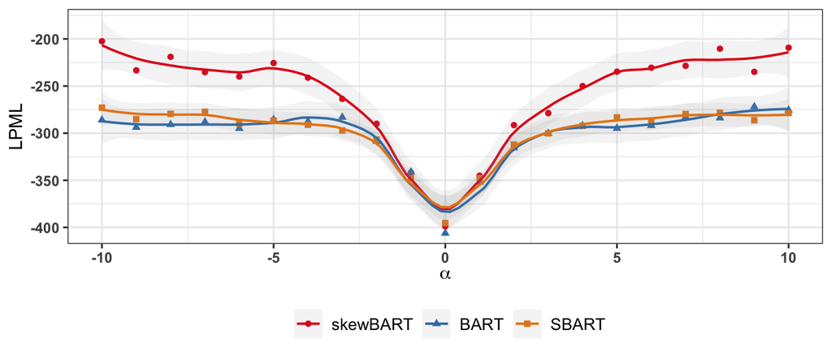

```r
library(ggplot2)
df <- data.frame(fitted = fitted_skewbart$y_hat_test_mean, mu = test_EY)
```

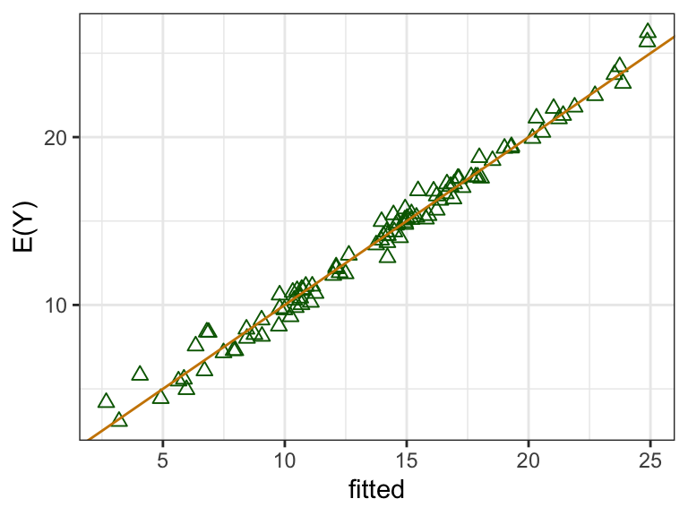

```r
ggplot(df, aes(x=fitted, y=mu)) + geom_point(shape=2, col = "darkgreen", size = 2) +
  theme_bw() + geom_abline(col = "orange3")  + ylab("E(Y)")
```